# Texas Accidents Group Analysis

Kumbaya

4/7/2020

# Welcome

[output not shown]

```r
#reading in clean data
raw <- read.csv("cleaned-accidents.csv")

head(raw)
```

```
##     Source Severity          Start_Time            End_Time Distance.mi.
## 1 MapQuest        2 2016-11-30 16:03:54 2016-11-30 17:20:00         0.01
## 2 MapQuest        2 2016-11-30 16:32:18 2016-11-30 17:47:02         0.00
## 3 MapQuest        2 2016-11-30 16:31:45 2016-11-30 17:46:34         0.00
## 4 MapQuest        2 2016-11-30 16:06:49 2016-11-30 17:27:00         0.01
## 5 MapQuest        3 2016-11-30 16:35:01 2016-11-30 17:49:39         0.01
## 6 MapQuest        2 2016-11-30 16:10:04 2016-11-30 17:25:00         0.01
##                                                                                                              Description
## 1                                                            Accident on RM-2222 Northland Dr at Mo Pac Expy Service Rd.
## 2                                                 Accident on Grand Canyon Dr between Westheimer Dr and Saint Johns Ave.
## 3                                                                             Accident on Saint Johns Ave at Cameron Rd.
## 4 #2 lane blocked and right hand shoulder blocked due to accident on TX-199 Jacksboro Hwy Westbound at Hanger Cutoff Rd.
## 5           #2 lane blocked and right hand shoulder blocked due to accident on I-820 Northbound at Exit 25 Trinity Blvd.
## 6                                                                                Accident on Camp Wisdom Rd at Clark Rd.
##         City  County Temperature.F. Weather_Condition Crossing Give_Way
```

[output cut: 20 more lines]

# A quick overview

```r
knitr::opts_chunk$set(warning=FALSE, message=FALSE)

####### ALL LIBRARIES USED ###########

#declare libraries
options(stringsAsFactors = FALSE)
library(tidyr)
library(dplyr)
library(highcharter)
library(plotly)

## Added by Alex Kahanek
library(lubridate)
library(padr)
library(tm)
library(DT)

######### READING IN CLEANED DATA ##########

raw <- raw %>%
    separate(Start_Time, c("Start_Date", "Start_Time"), sep = " ") %>%
  separate(End_Time, c("End_Date", "End_Time"), sep = " ") %>%
  mutate(
    wday = weekdays(as.Date(Start_Date, format = "%Y-%m-%d"))
  )

##### GETTING DALLAS DATA #######

#list for counties
dallas_plano_irving <- c("Collin", "Dallas", "Denton", "Ellis", "Hunt", "Kaufman", "Rockwall")

dfw <- data.frame() #create new variable

for (county in dallas_plano_irving){ #loop to grab all
  dfw <- raw %>%
  subset(County == county) %>%
    bind_rows(dfw)
}

####### GENERAL SUMMARIES #######

#getting counts for all cities
city_count <- raw %>%
  group_by(City) %>%
  dplyr::summarise(
    accidents = dplyr::n(),
    mean_sev = mean(Severity)
  ) %>%
  arrange(-accidents)

#getting counts for all counties
county_count <- raw %>%
  group_by(County) %>%
  dplyr::summarise(
    accidents = dplyr::n(),
    mean_sev = mean(Severity)
  ) %>%
  arrange(-accidents)

#getting counts for all dates
date_count <- raw %>%
  group_by(Start_Date) %>%
  dplyr::summarise(
    accidents = dplyr::n(),
    mean_sev = mean(Severity)
  ) %>%
  arrange(-accidents)

#getting counts for all severities
severity_count <- raw %>%
  group_by(Severity) %>%
  dplyr::summarise(
    accidents = dplyr::n(),
    mean_sev = mean(Severity)
  ) %>%
  arrange(-accidents)

#getting counts for all weekdays
weekday <- raw %>%
  group_by(wday) %>%
  dplyr::summarise(
    accidents = dplyr::n(),
    mean_sev = mean(Severity)
  ) %>%
  arrange(-accidents)

#getting missing date values
date_count <- date_count %>%
  mutate(
    Date = as.Date(Start_Date, format="%Y-%m-%d")
  )

#first and last day of data
min_d<- min(date_count$Date)
max_d<- max(date_count$Date)
```

Lets start with taking a look at a general overview of the data.

## Overview of Severities

```r
##### TREEMAP FOR SEVERITY ########
hc <- severity_count %>%
  hchart(type="treemap", hcaes(x=paste("Severity:", Severity, sep=" "), value=accidents, color=accidents)) %>%
  hc_colorAxis(minColor = "#F4D03F", maxColor="red") %>%
  hc_add_theme(hc_theme_flat()) %>%
  hc_title(text = "Total Accidents by Severity, for Texas",
           align = "left") %>%
  hc_subtitle(text = "color corrosponds to the number of accidents",
           align = "left") %>%
  hc_tooltip(formatter = JS("function(){
                            return (' Severity: ' + this.point.Severity + ' <br> # Accidents: ' + this.point.accidents)}"))

hc
```

[interactive chart not shown]

This Treemap can tell us a few things about the Severity Category in the data, for example:

- There are 4 Severity levels in the data,
  - the Severity ranges on a scale of 1 - 4,
    - Severity 1: 120 accidents
    - Severity 2: 215027 accidents
    - Severity 3: 79467 accidents
    - Severity 4: 3448 accidents
- 98% of the recorded accidents are categorized as Severity level 2 or 3.
  - 72% of the recorded accidents are level 2, respectively.
  - 26% of the recorded accidents are level 3, respectively.
- 1.1% of the recorded accidents are categorized as level 4, the most severe accident.
- While less than 0.04% of the recorded accidents are considered a Severity level of 1.
  - This could be due to an underreporting of these accidents.
- The total number of recorded accidents in Texas is 298062 accidents.

## Overview of Counties

```r
#### TREEMAP FOR COUNTY COUNT ######
hc <- county_count %>%
  slice(1:8) %>%
  hchart(type = "bar",
         hcaes(x=County, y=accidents, color=County)) %>%
  hc_add_theme(hc_theme_flat()) %>%
  hc_yAxis(title = list(text = "# of Accidents")) %>%
  hc_title(text = "Total Accidents by County, in Texas",
           align = "left") %>%
  hc_tooltip(formatter = JS("function(){
                            return (' County: ' + this.point.County + ' <br> # Accidents: ' + this.point.accidents + ' <br> Severity: ' + this.point.mean_sev.toFixed(2))}"))

hc
```

[interactive chart not shown]

From the above, we can see the four most accident prone Counties:

- Harris County, TX:
  - 99023 recorded accidents
  - mean severity level of 2.24
- Dallas County, TX:
  - 68149 recorded accidents
  - mean severity level of 2.41
- Travis County, TX:
  - 63603 recorded accidents
  - mean severity level of 2.28
- Bexar County, TX:
  - 22206 recorded accidents
  - mean severity level of 2.28

The graph shows the disparity of the top three Counties and the preceeding Counties. With the third highest County, Travis County, having 41397 more accidents than the fourth highest County, Bexar County.

## Overview of Cities

```r
#### TREEMAP FOR CITY COUNTS ######
hc <- city_count %>%
  slice(1:8) %>%
  hchart(type = "treemap",
         hcaes(x=City, value=accidents, color=mean_sev)) %>%
  hc_colorAxis(minColor = "#F4D03F", maxColor="red") %>%
  hc_add_theme(hc_theme_flat()) %>%
  hc_title(text = "Total Accidents by City, in Texas",
           align = "left") %>%
  hc_subtitle(text = "color corrosponds to the mean severity level",
           align = "left") %>%
  hc_tooltip(formatter = JS("function(){
                            return (' City: ' + this.point.City + ' <br> # Accidents: ' + this.point.accidents + ' <br> Severity: ' + this.point.mean_sev.toFixed(2))}"))

hc
```

[interactive chart not shown]

From the graph, The five most accident prone Cities in Texas are:

- Houston, TX
  - 93245 recorded accidents
  - mean severity level of 2.23
- Austin, TX
  - 58553 recorded accidents
  - mean severity level of 2.13
- Dallas, TX
  - 57823 recorded accidents
  - mean severity level of 2.38
- San Antonio, TX
  - 21613 recorded accidents
  - mean severity level of 2.27
- El Paso, TX
  - 9352 recorded accidents
  - mean severity level of 2.12

Again, we are seeing a huge disparity of the top three Cities and the preceeding Cities.

- Houston, TX has 31.2% of the total accidents in Texas.
- Austin, TX has 19.6% of the total accidents in Texas.
- Dallas, TX has 19.3% of the total accidents in Texas.

These three cities combined have 70% of the total recorded accidents. meaning the other 710 Cities make up for the remaining 30%.

## Complete Timeline

```r
#get all dates
alldates <- seq(min_d, max_d,1)

#take out dates that occur in data
alldates <- alldates %>%
  subset(!(alldates %in% date_count$Date))

#create dataframe of all dates, with 0 accidents
alldates <- data.frame(Date=alldates, accidents=0, mean_sev=0)

#combining missing dates with old data
total <- alldates %>%
  bind_rows(date_count) %>%
  subset(select = c(Date, accidents, mean_sev)) %>%
  arrange(Date) %>%
  mutate(
    wday = weekdays(Date) #get weekdays
  )

total %>%
  hchart(type="column", hcaes(x=Date, y=accidents), color="black") %>%
  hc_add_theme(hc_theme_flat()) %>%
  hc_title(text = "Total Accidents by Date",
           align = "left") %>%
  hc_yAxis(title = list(text = "# of Accidents")) %>%
  hc_xAxis(title = "", type = "datetime", dateTimeLabelFormats = list(day = '%Y/%m')) %>%
  hc_tooltip(formatter = JS("function(){
                            return (' Date: ' + this.point.Date)+ ' <br> Weekday: ' + this.point.wday + ' <br> # Accidents: ' + this.point.accidents + ' <br> Mean Severity: ' + this.point.mean_sev.toFixed(2)}"))
```

[interactive chart not shown]

This graph shows exactly how much data is in this data set, as well as any patterns in the number of Accidents. For example,

- The graph seems to show high variation throughout the individual weeks,
  - this can be tested by looking at the accidents per weekday.
- There only seems to be one major dip in the data from May 24, 2017 to June 1, 2017.
- There might be a small decline in the number of accidents over time,
  - more analysis on this will need to be done to see if this is true.

## Pearsons r and r<sup>2</sup>

Lets see if Severity, Distance of Accidents, and Temperature are correlated! To do this, we need use use pearsons r and pearsons r squared.

First, lets take a look at pearsons r.

```r
raw_cor <- raw %>%
  subset(!is.na(Severity)) %>%
  subset(!is.na(Distance.mi.)) %>%
  subset(!is.na(Temperature.F.)) %>%
  subset(select = c(Severity, Distance.mi., Temperature.F.)) %>%
  as.matrix() %>%
  cor()

raw_cor
```

```
##                   Severity Distance.mi. Temperature.F.
## Severity        1.00000000   0.14062302    -0.02974895
## Distance.mi.    0.14062302   1.00000000    -0.01100098
## Temperature.F. -0.02974895  -0.01100098     1.00000000
```

Lets check how well correlated these factors are, we can do this simply by just squaring the above correlation.

```r
#lets take a look at the severity matched with the start time
raw_cor_2 <- raw_cor %>%
  '^'(2) %>%
    round(5) %>% #round
  hchart() %>% #graph
  hc_colorAxis(minColor = "#F4D03F", maxColor="red") %>%
  hc_add_theme(hc_theme_flat()) %>%
  hc_title(text = "Pearsons r squared matchup",
           align = "left") %>%
  hc_subtitle(text = "For TX accidents",
              align = "left") %>%
   hc_xAxis(categories = list("Severity", "Distance of Accident", "Temperature")) %>%
  hc_yAxis(categories = list("Severity", "Distance of Accident", "Temperature"))%>%
   hc_legend(align = "left") %>%
  hc_plotOptions(
           series = list(
             boderWidth = 0,
             dataLabels = list(enabled = TRUE)))

raw_cor_2
```

[interactive chart not shown]

All of the r squared values are very low, with the highest being Severity and Distance of the Accident (0.01977). This tells us that only ~1.9% of the Severity samples can be explained by the Distance of the Accident.

As all of these r<sup>2</sup> values are very low, this suggests that none of the factors can be explained by the other.

- ie, the Distance an Accident occurs has little to do with the Severity of the Accident.
  - The same can be said for all of the other matchups as well.

# Analysis of Day and Night

The goal is to see if there are more accident during days or nights time.

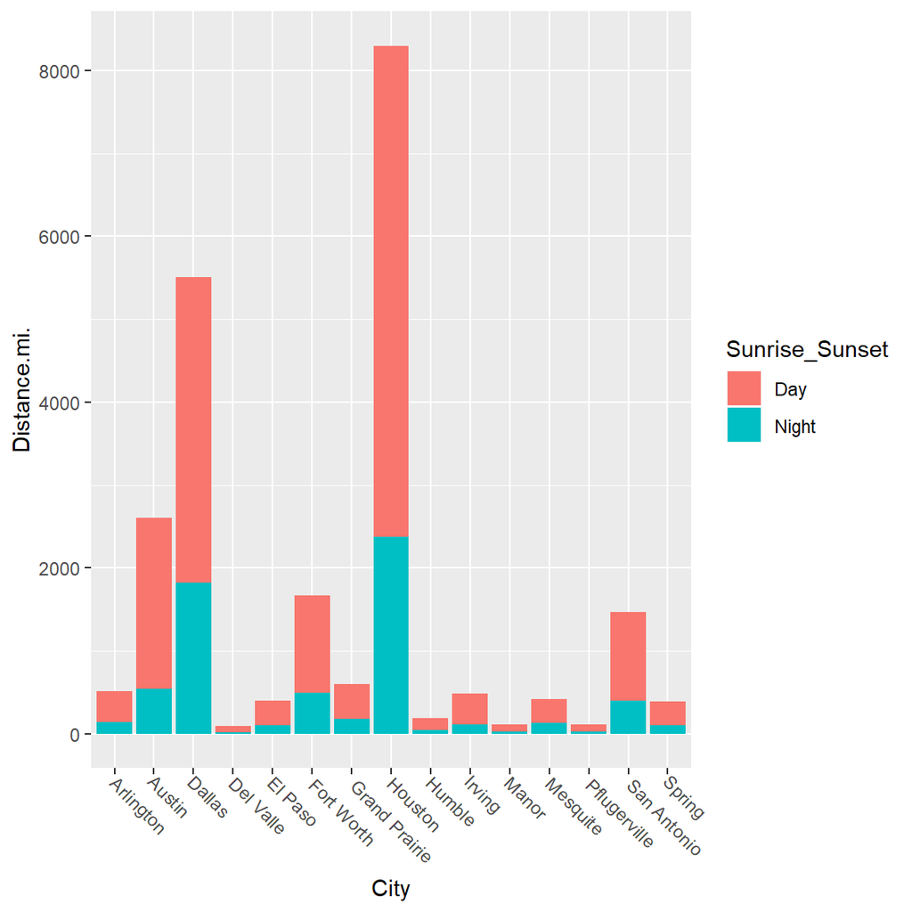

```r
rm(list = ls(all.names = TRUE))

#reading in clean data
raw <- read.csv("cleaned-accidents.csv")

raw <- raw %>%
    separate(Start_Time, c("Start_Date", "Start_Time"), sep = " ") %>%
  separate(End_Time, c("End_Date", "End_Time"), sep = " ") %>%
  mutate(
    wday = weekdays(as.Date(Start_Date, format = "%Y-%m-%d"))
  )

top_fifty <- raw %>%
  group_by(City,Distance.mi., Sunrise_Sunset) %>%
  summarise(
    n= n()
  )

day <- top_fifty %>%
  subset(Sunrise_Sunset == "Day") %>%
  arrange(-n)

day <- day[1:15,]

night <- top_fifty %>%
  subset(Sunrise_Sunset == "Night") %>%
  arrange(-n)
night<-night[1:15,]

topfifteen<-raw%>%
  group_by(City)%>%
  summarize(n=n())%>%
  arrange(-n)
topfifteen<- topfifteen[1:15,]
sun<-raw%>%
  filter(City%in% topfifteen$City)

gg <- ggplot(sun,aes(x=City,y=Distance.mi.,fill=Sunrise_Sunset))+
  geom_bar(stat="identity")+
  theme(axis.text.x = element_text(angle=-45, hjust=-0.1))
gg
```

# Analysis of Weather and Severity

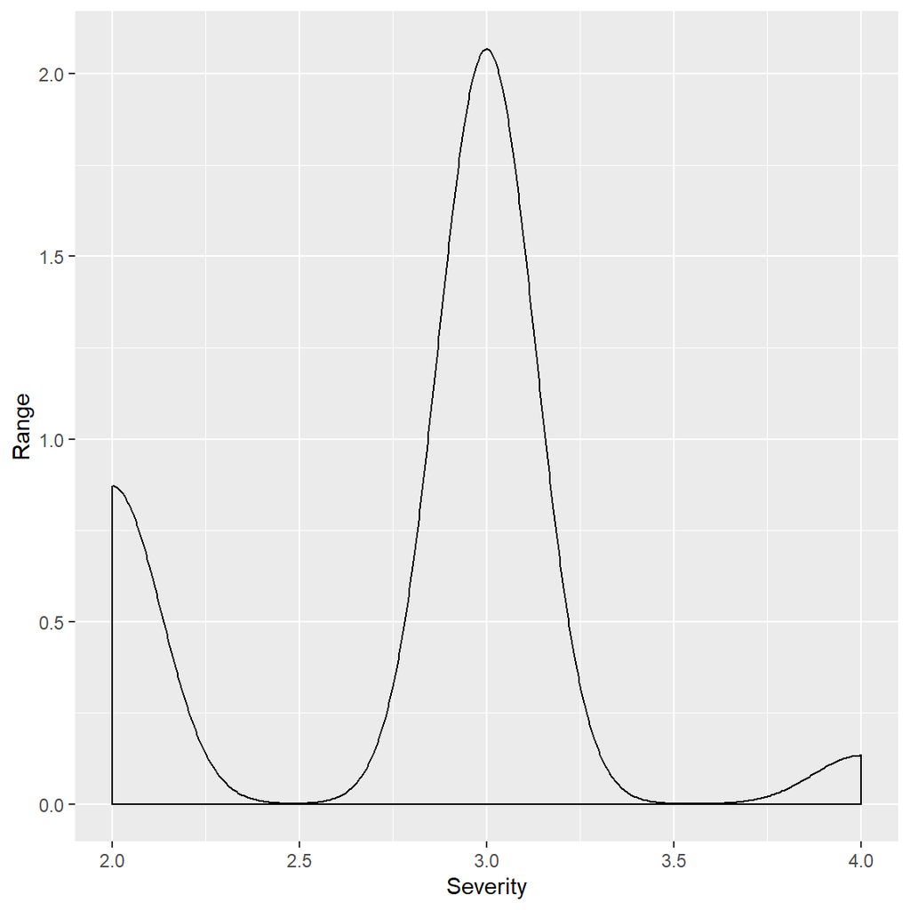

```r
rm(list = ls(all.names = TRUE))

accidents<- read.table('cleaned-accidents.csv',header = TRUE, sep = ',')

df<-accidents
top_fifty <-df %>%
  group_by(County) %>%
  summarise(
    n= n()
  )

#Severity in the city of Denton with a density and a histogram chart

denton <- df %>%
  subset(City == "Denton")

accidents1 <- ggplot(denton, aes(Severity))
accidents1 + geom_density() + labs(x = "Severity", y = "Range")
```

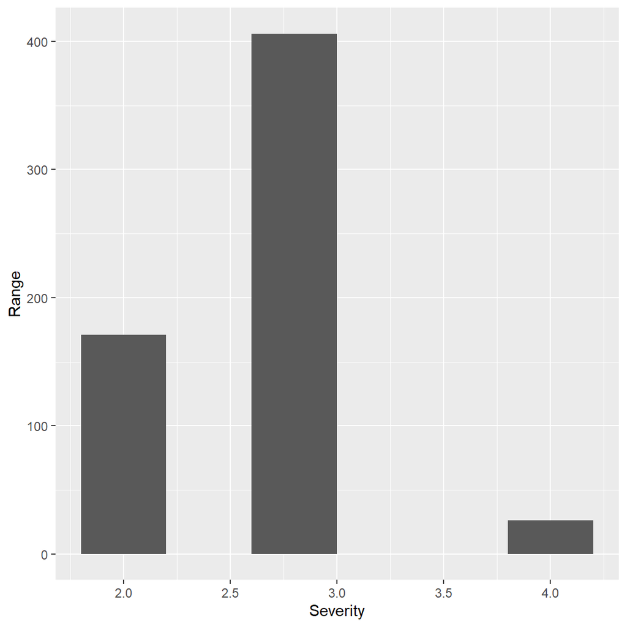

```r
accidents1 <- ggplot(denton, aes(Severity))
accidents1 + geom_histogram(binwidth = 0.4) + labs(x = "Severity", y = "Range")
```

Both of the plots show basically the same thing. One of them is a density plot and the other is a histogram. This histogram is a very easy plot to understand. you can see which serverity is the highest by just looking at the chart. The denisty plot visualises the distribution of data over a continuous interval or time period. The plot only uses Denton and how severity each accident is in that city.As you can see in the plot that the severity is averaging around 3.

## How temperature matches with the serverity of eatch county

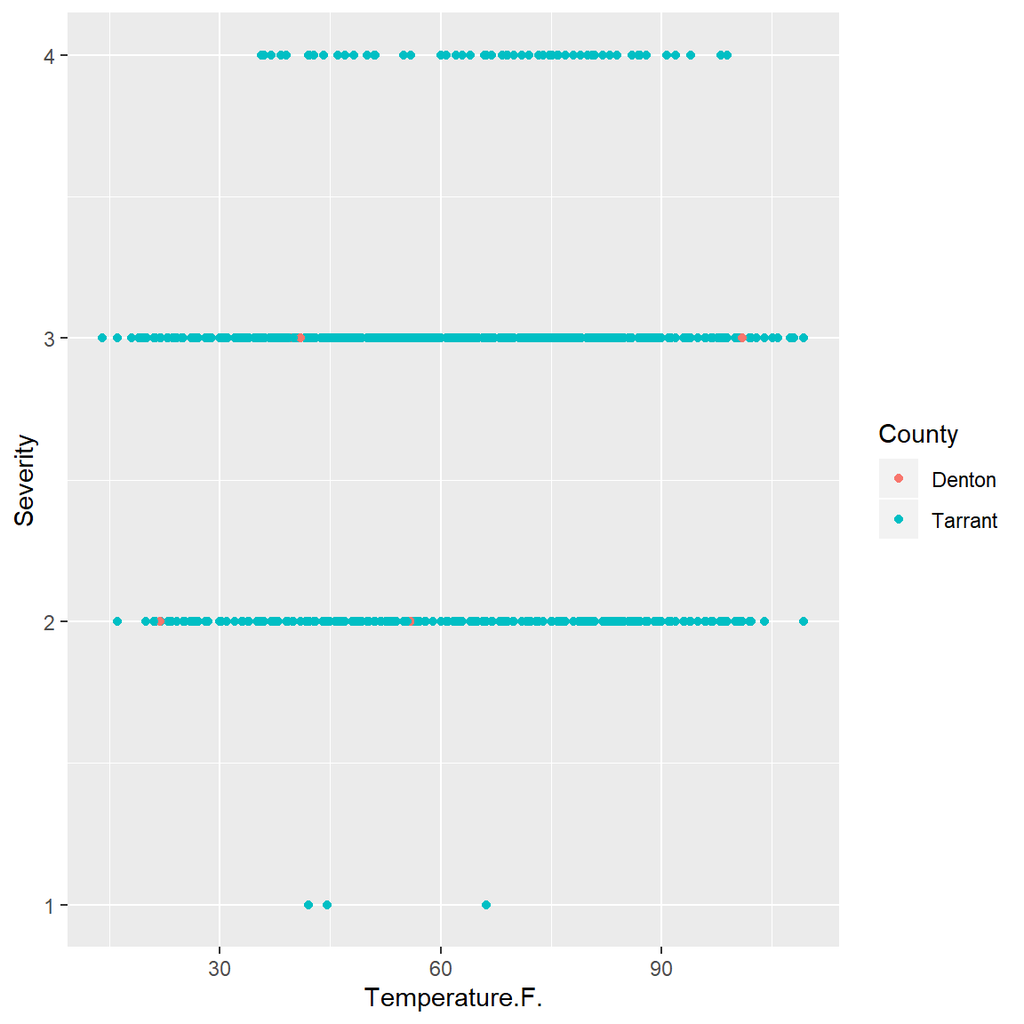

```r
county <- df %>%
  subset(City == "Fort Worth")

ggplot(data =county )+
  geom_point(mapping=aes(Temperature.F., Severity, color = County))
```

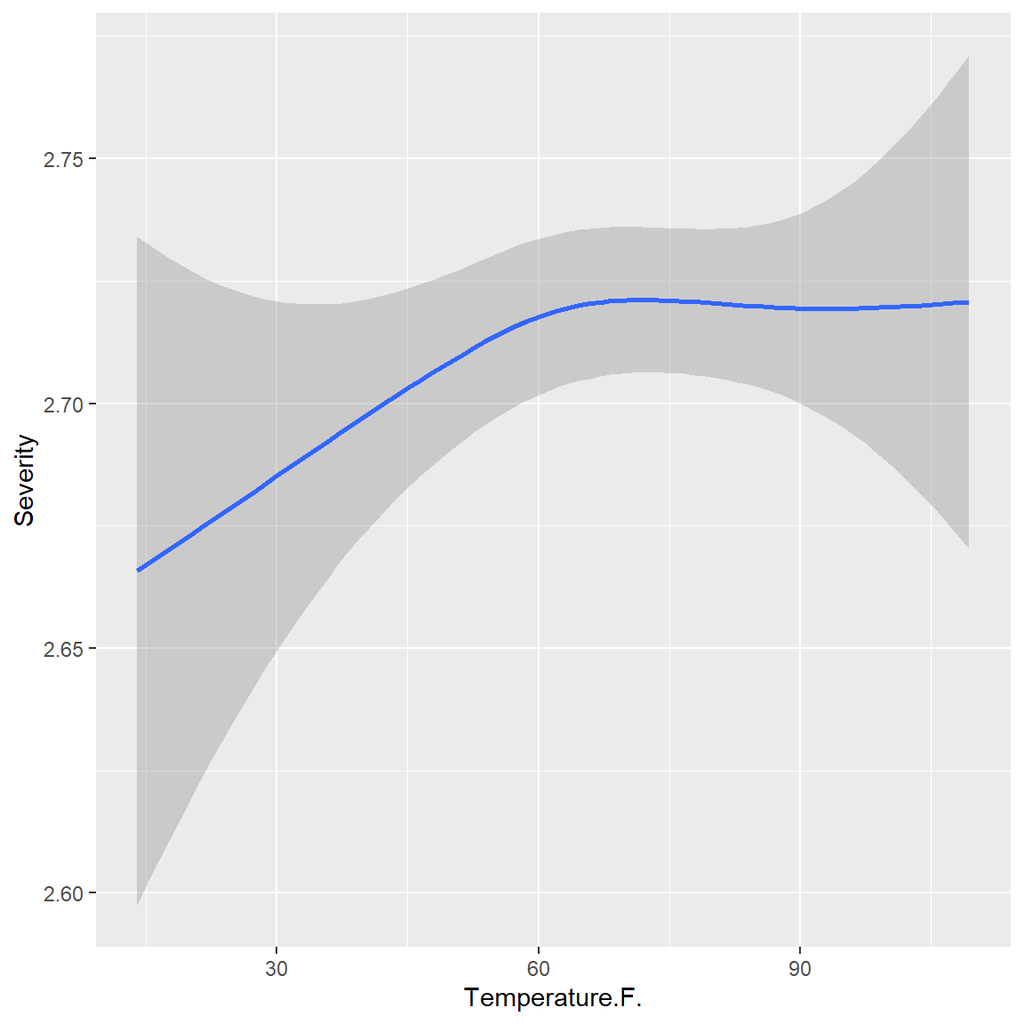

```r
ggplot(data = county)+
  geom_smooth(mapping=aes(x=Temperature.F., y=Severity,))
```

```r
#pairs(~Severity+Description+Weather_Condition+Temperatur#e.F.,data=county,main="Scatterplot Matrix", cex= .25)
```

# Analysis of Weekdays

In this Analysis, I will dive into the differences of the recorded accidents according to the day of the week!

```r
##### ADDED LIBRARIES #####
#library(lubridate)
#library(padr)
#library(tm)
#library(DT)
###########################
#### CLEARING VARIABLES ###
rm(list = ls(all.names = TRUE))

### GETTING A NEW RAW
# This is to make merging the analysis into the main file easier
raw <- read.csv("cleaned-accidents.csv")

raw <- raw %>%
    separate(Start_Time, c("Start_Date", "Start_Time"), sep = " ") %>%
  separate(End_Time, c("End_Date", "End_Time"), sep = " ") %>%
  mutate(
    wday = wday(Start_Date, label=TRUE)
  )

#getting counts for all dates
date_count <- raw %>%
  group_by(Start_Date) %>%
  dplyr::summarise(
    accidents = dplyr::n(),
    mean_sev = mean(Severity)
  ) %>%
  arrange(-accidents)

#getting missing date values
date_count <- date_count %>%
  mutate(
    Date = as.Date(Start_Date, format="%Y-%m-%d")
  )

#first and last day of data
min_d<- min(date_count$Date)
max_d<- max(date_count$Date)

#### PLOTTING ######
hc <- date_count %>%
  subset(select = c(Date, accidents, mean_sev)) %>%
  mutate(
    wday = wday(Date, label=TRUE) #get weekdays
  ) %>%
  group_by(wday) %>%
  dplyr::summarise(
    accidents = sum(accidents),
    mean_sev = mean(mean_sev)
  ) %>%
  ungroup() %>%
  hchart(type= "bar", hcaes(x=wday, y=accidents)) %>%
  hc_add_theme(hc_theme_flat()) %>%
  hc_title(text = "Total Accidents by Day of Week",
           align = "left") %>%
  hc_yAxis(title = list(text = "# of Accidents")) %>%
  hc_xAxis(title = list(text = "")) %>%
  hc_tooltip(formatter = JS("function(){
                            return (' Day of Week: ' + this.point.wday + ' <br> # Accidents: ' + this.point.accidents + ' <br> Mean Severity: ' + this.point.mean_sev.toFixed(2))}"))

#call plot
hc
```

[interactive chart not shown]

As shown, there is a great desperity between the Monday - Friday, and Saturday/Sunday.

- While Monday to Friday has a range of 3,346 accidents. Monday to Sunday has a range of 44,344 accidents.
  - Monday has 18.7% of the total accidents.
  - Tuesday has 18.5% of the total accidents.
  - Wednesday has 18.5% of the total accidents.
  - Thursday has 17.9% of the total accidents.
  - Friday has 17.6% of the total accidents.
  - Saturday has 4.7% of the total accidents.
  - Sunday has 3.8% of the total accidents.

While this huge drop is apparent on the weekend, one reason why might this occur is; there are less people are working, causing less people to be on the roads.

Now lets take a look into if this has any differences throughout the years.

```r
#### PLOTTING #######

date_count %>%
  subset(select = c(Date, accidents, mean_sev)) %>%
  mutate(
    Year = as.numeric(format(date_count$Date, "%Y"))
  ) %>%
  mutate(
    wday = wday(Date, label=TRUE) #get weekdays
  ) %>%
  group_by(wday,Year) %>%
  dplyr::summarise(
    accidents = sum(accidents),
    mean_sev = mean(mean_sev)
  ) %>%
  ungroup() %>% #plot starts below
  hchart(type= "bar", hcaes(x=wday, y=accidents, group = Year)) %>%
  hc_add_theme(hc_theme_flat()) %>%
  hc_title(text = "Total Accidents by Day of Week",
           align = "left") %>%
  hc_yAxis(title = list(text = "# of Accidents")) %>%
  hc_xAxis(title = list(text = "")) %>%
  hc_tooltip(formatter = JS("function(){
                            return (' Year: ' + this.point.Year + '<br>  Day of Week: ' + this.point.wday + ' <br> # Accidents: ' + this.point.accidents + ' <br> Mean Severity: ' + this.point.mean_sev.toFixed(2))}"))
```

[interactive chart not shown]

```
You can de-select anything in the legend to get a closer look at the years.
```

Here we can see a significant drop in the number of accidents in 2016, this is due to not having the complete year. Remember, this dataset starts on July 14, 2016.

Despite this, we still see a massive drop in accidents occuring on a Saturday or a Sunday.

Lets dive into the text data to see if there are any indcations to why there is a massive drop on Saturday and Sunday.

```r
####### FUNCTION TO GRAB HIGHWAYS #######
get_hwy <- function(data){
  new_data <- data.frame()
  #get temp year
  temp <- data

    #seperate text data into words, by weekday
  new_data <- stack(tapply(temp$Description, temp$wday, function(x) scan(text=x, what=''))) %>%
      mutate(
        values = ifelse(grepl(values, pattern="\\-"), removePunctuation(values, preserve_intra_word_dashes = TRUE), NA)
      ) %>%
      mutate( #remove blank values
        values = ifelse(values == "", NA, values)
      ) %>%
      subset(!is.na(values)) %>% #delete NA's
      group_by(ind) %>%
      mutate( #toupper all letters
        values = toupper(values)
      ) %>%
      dplyr::rename( #rename
        "words" = values,
        "wday" = ind
      ) %>%
      bind_rows(new_data) #bind back

  return(new_data)
}


#get text data
text_wday <- raw %>%
  subset(select = c(wday, Description, Start_Date)) %>%
  mutate(
    year = as.numeric(format(as.Date(raw$Start_Date,format = "%Y-%m-%d"), "%Y"))
  ) %>%
  subset(select = -c(Start_Date)) %>%
  get_hwy()

#subset into week
wk = c("Mon", "Tue", "Wed", "Thu", "Fri")
week <- data.frame()
for(day in wk){
  week <- text_wday %>%
  subset(wday == day) %>%
    bind_rows(week)
}
week <- week %>%
  subset(select = words) %>%
  dplyr::count(words) %>%
  arrange(-n) %>%
  mutate(
    "weekday hwy" = words,
    "weekday count" = n,
    rank = 1:nrow(.)
  ) %>%
  subset(select = c("weekday hwy", "weekday count", "rank"))

#subset into weekend
wkd = c("Sat", "Sun")
weekend <- data.frame()
for(day in wkd){
  weekend <- text_wday %>%
  subset(wday == day) %>%
    bind_rows(weekend)
}
weekend <- weekend %>%
  subset(select = words) %>%
  dplyr::count(words) %>%
  arrange(-n) %>%
  mutate(
    "weekend hwy" = words,
    "weekend count" = n,
    rank = 1:nrow(.)
  ) %>%
  subset(select = c("weekend hwy", "weekend count", "rank"))

#combining datasets for a data table
week %>%
  slice(1:80) %>%
  bind_cols(weekend %>%
              slice(1:80)) %>%
  subset(select = -c(rank1)) %>%
  datatable()
```

|  | weekday hwy | weekday count | rank | weekend hwy | weekend count |
| --- | --- | --- | --- | --- | --- |
| 1 | I-35 | 13291 | 1 | I-35 | 1523 |
| 2 | I-45 | 7960 | 2 | I-45 | 1376 |
| 3 | I-10 | 7341 | 3 | I-35E | 1365 |
| 4 | I-635 | 6909 | 4 | I-635 | 1269 |
| 5 | I-35E | 6855 | 5 | I-30 | 1157 |
| 6 | I-30 | 6614 | 6 | I-10 | 872 |
| 7 | I-610 | 5752 | 7 | I-20 | 864 |
| 8 | I-20 | 4852 | 8 | I-610 | 840 |
| 9 | US-290 | 3782 | 9 | US-75 | 653 |
| 10 | US-75 | 3561 | 10 | I-69 | 582 |

[output cut: 70 more lines]

```
This is a lookup table, you can use this to search through the top 80 ranks!
```

These are the top 10 accident prone highways for the weekdays and the weekend!

Every other highway tends to change ranks, which could suggest that certain highways get proportionally less traffic on the weekdays, as opposed to the weekends, or vice versa!